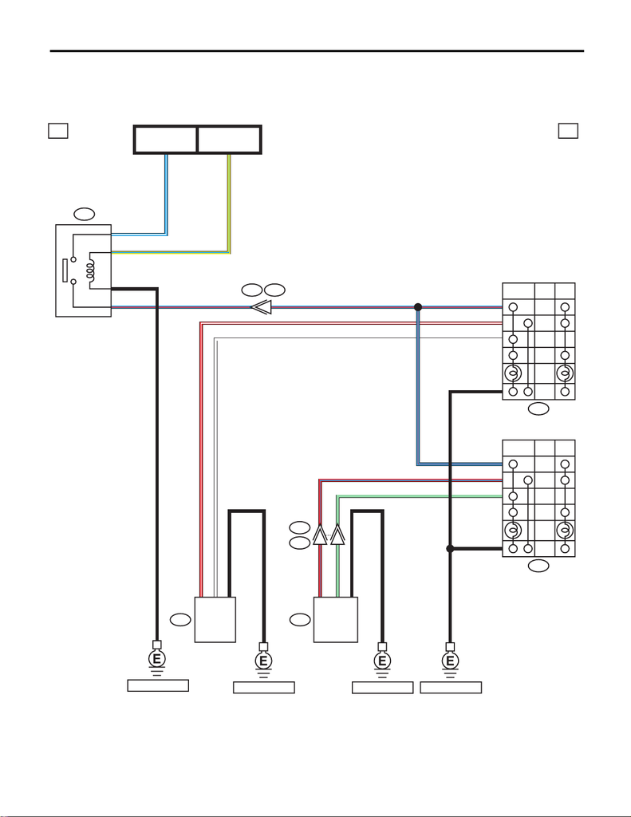

WI-370

Seat Heater System

WIRING SYSTEM

48.Seat Heater System

A: WIRING DIAGRAM

1. ENGINE TYPE FA

WI-44562

14

B220

B97 R1

R41R44

Y/L

L/W

L/R36

B

L/W

Y/L

39

37

38

L/RL/R

R/L4

LG3

B1

R/W4

W3

B1

B

B

B

W

B

1

3

B3

LG 1

R/L 4

L/R 2

L/R

R/W

2

4

B

9

10

R81

R82

R42

HI OFF LO

R43

HI OFF LO

SEAT HEATER LH

SEAT HEATER RH

SEAT HEATER

RELAY

FB-20

F/B FUSE NO. 6

(ACC)

FB-5

F/B FUSE NO. 17

(B)

REF. TO GND [h]REF. TO GND [f]REF. TO GND [g]

REF. TO GND [d]

SEAT HEATER SWITCH RH

SEAT HEATER SWITCH LH

[figure not shown]

WI-371

Seat Heater System

WIRING SYSTEM

B220

12

13

14 15

16

18

19 21 22

20

17

24

5

3

17

9

8

6

32 33

34

35

28262423

25

27

29

30

31

36 37

38

40

41 43 44

42

39

WI-44563

1b 1b

89

19 20

1234 567

10 11 12 13 14 15 16 17 18

B97

R44

R41

12

34

R42

12

34

(B)

R82

1

9

234 5678

10 11 12 14 15 16 17 18 1913

(L)

R43

34

12

RELAY HOLDER

LIST OF CONNECTORS

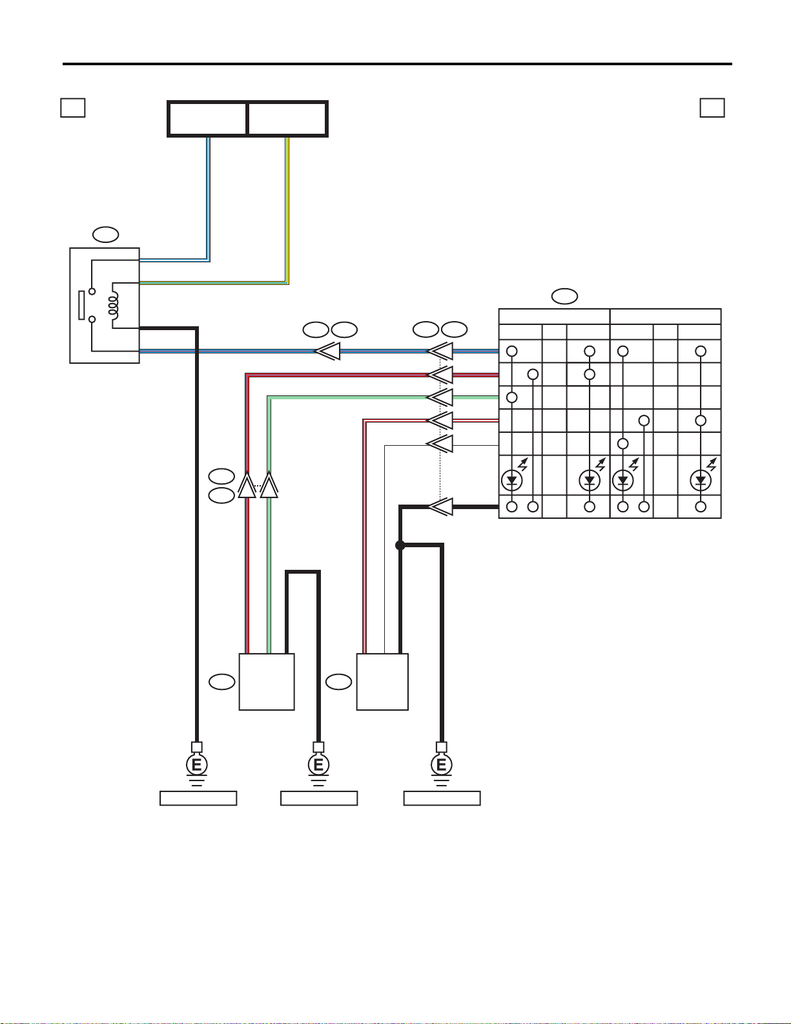

WI-372

Seat Heater System

WIRING SYSTEM

2. ENGINE TYPE EJ

WI-45450

14

B220

B97 R1

R41 R44

Y/L

L/W

L/R36

B

L/W

Y/L

39

37

38

L/RL/R

R/L4

LG3

B1

R/W4

W3

B1

B

B

B

9

10

R81

R82

R34 AD6

4

R/L 1

2

R/W 3

1

W8

3

B2

15

L/R 7

5

LG

R/L

R/W

W

B

L/R

LG 4

AD8

HI OFF LO

R

HI OFF LO

L

SEAT HEATER LH

SEAT HEATER RH

SEAT HEATER

RELAY

FB-20

F/B FUSE NO. 6

(ACC)

FB-5

F/B FUSE NO. 17

(B)

REF. TO GND [f] REF. TO GND [g]REF. TO GND [d]

SEAT HEATER SWITCH

[figure not shown]

WI-373

Seat Heater System

WIRING SYSTEM

B220

12

13

14 15

16

18

19 21 22

20

17

24

5

3

17

9

8

6

32 33

34

35

28262423

25

27

29

30

31

36 37

38

40

41 43 44

42

39

AD8

12 3

45678

WI-45451

2b 2b

89

19 20

1234 567

10 11 12 13 14 15 16 17 18

B97

R44

R41

12

34

(B)

R82

1

9

234 5678

10 11 12 14 15 16 17 18 1913

R34

123

161514

546789

17 18 19 2013121110

RELAY HOLDER

LIST OF CONNECTORS